### Вариационный анализ канцерогенного риска

Формула для расчета **индивидуального канцерогенного риска** следующая: R<sub>инд.канц.</sub> = LADD<sub>пер.</sub> ‧ SF

где SF – фактор канцерогенного потенциала $\left[\frac{мг}{кг\cdotсутки}\right]$

Таблица 1. Стандартные факторы экспозиции, используемые при расчете дозы, и их вариабельность при анализе неопределенности

И вопрос сразу же. Почему вроде бы как формула одна и та же, но параметр V в ней имеет разный смысл. По хорошему надо поменять.

| Параметр | Характеристика | Тип распределения | Вариабельность (доверительный интервал значений) |
| --- | --- | --- | --- |
| V | Суточное пероральное поступление почвы в организм взрослого человека, мг/день | константа | 100 |
| EF | частота воздействия, дней/год | триангулярное | 270 (180-365) |
| ED | продолжительность воздействия, лет | логнормальное | 30 (19-43) |
| BW | масса тела, кг | логнормальное | 70 (55-80) |
| AT | период осреднения экспозиции, лет | константа | 70 |
| $C_{эл}$ | концентрация элемента, $мг/м^3$ | нормальное | $C_{эл}$ ± SD |

Задаем факторы канцерогенного потенциала SF для каждого из веществ. А также средствами языка R задаем остальные коэффициенты, входящие в формулу расчета R<sub>инд.канц.</sub> с соответствующими распределениями из таблицы 1, и концентрации элементов также в виде распределения. Распределение концентраций будем моделировать с теми же параметрами, полученными из расчета среднего и ошибки реальных концентраций этих элементов в 10 пробах г. Междуреченска за 2015 год.

Средние значения и ошибка (SD) концентраций элементов для проверки

| Be | Cr | Co | Ni | As | Cd | Pb |
| --- | --- | --- | --- | --- | --- | --- |
| 1.24 | 75.80 | 18.33 | 39.20 | 27.86 | 0.13 | 16.480 |
| 1.91 | 66.35 | 15.38 | 34.36 | 13.37 | 0.32 | 34.012 |
| 1.53 | 84.04 | 15.45 | 44.45 | 10.50 | 0.21 | 18.620 |
| 1.53 | 83.56 | 14.88 | 36.75 | 13.81 | 0.33 | 19.210 |
| 2.06 | 88.81 | 18.22 | 48.36 | 37.46 | 0.29 | 25.350 |
| 1.72 | 71.52 | 14.76 | 40.38 | 25.15 | 1.19 | 43.230 |
| 2.26 | 72.93 | 15.25 | 41.45 | 47.21 | 0.29 | 17.820 |
| 1.69 | 54.74 | 14.01 | 29.99 | 26.10 | 0.33 | 28.170 |
| 2.45 | 79.73 | 15.85 | 39.01 | 39.51 | 1.07 | 30.340 |
| 1.99 | 77.32 | 15.19 | 38.69 | 28.14 | 0.85 | 39.720 |

| Be | Cr | Co | Ni | As | Cd | Pb |
| --- | --- | --- | --- | --- | --- | --- |
| 1.8380 | 75.4800 | 15.7320 | 39.2640 | 26.9110 | 0.5010 | 27.2952 |
| 0.3672 | 9.8516 | 1.4267 | 5.0819 | 12.0764 | 0.3834 | 9.5138 |

Моделируем распределение концентраций элементов с полученными средними и дисперсией, подставляем в формулу для LADD и все перемножаем (не забываем умножить на 10<sup>-6</sup>).

Средние значения и ошибка LADD при расчете с учетом коэффициентов и концентраций в виде распределения

| Be | Cr | Co | Ni | As | Cd | Pb |
| --- | --- | --- | --- | --- | --- | --- |
| 9.74048e-07 | 4.03406e-05 | 8.35709e-06 | 2.08202e-05 | 1.37171e-05 | 2.63325e-07 | 1.44277e-05 |
| 5.37538e-07 | 2.11179e-05 | 4.36642e-06 | 1.08165e-05 | 1.00730e-05 | 2.76199e-07 | 9.16594e-06 |

Дальше считаем R<sub>инд.канц.</sub>, Умножаем полученные LADD на SF.

Средние значения и ошибка R<sub>инд.канц.</sub>

| Be | Cr | Co | Ni | As | Cd | Pb |
| --- | --- | --- | --- | --- | --- | --- |
| 8.18200e-06 | 1.69431e-03 | 8.18994e-05 | 1.74890e-05 | 2.05757e-04 | 1.65895e-06 | 6.05962e-07 |
| 4.51532e-06 | 8.86951e-04 | 4.27909e-05 | 9.08582e-06 | 1.51094e-04 | 1.74005e-06 | 3.84970e-07 |

### Уровни R<sub>инд.канц.</sub> для соответствующих вероятностей

|  | Be | Cr | Co | Ni | As | Cd | Pb |
| --- | --- | --- | --- | --- | --- | --- | --- |
| 25% | 5.10e-06 | 0.0010661 | 5.22e-05 | 1.11e-05 | 0.0001046 | 6.0e-07 | 3e-07 |
| 50% | 7.10e-06 | 0.0015240 | 7.14e-05 | 1.55e-05 | 0.0001739 | 1.3e-06 | 5e-07 |
| 75% | 1.01e-05 | 0.0021185 | 1.01e-04 | 2.23e-05 | 0.0002747 | 2.3e-06 | 8e-07 |

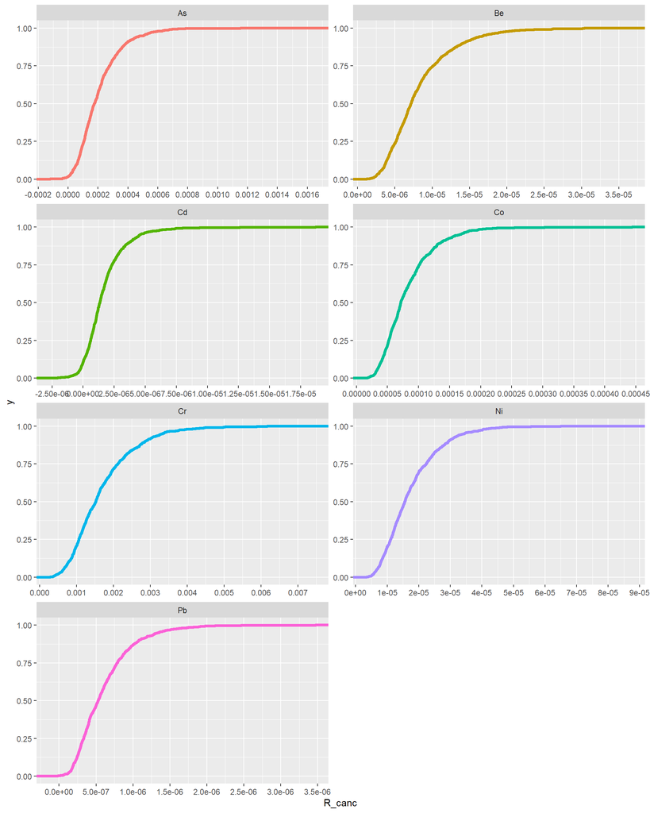